# Evidence_1_Initial_Analysis

## Name: Alvaro González Martínez A01646343

### 1. Investiga, ¿Cuál es la situación actual de COVID-19 a nivel mundial, en México, en tu estado de origen y en tu municipio, alcaldía o colonia? Puedes iniciar tu búsqueda en el sitio de Johns Hopkins

### A nivel mundial, la situación del COVID-19 actualmente ha cambiado desde los momentos más dificiles de la pandemia. De acuerdo a los datos disponibles del Johns Hopkins hasta marzo de 2023 se habían registrado 676,609,955 casos confirmados y 6,881,955 defunciones por COVID-19 a nivel mundial.

### La magnitud de la pandemia y el peligro de contagiarte por el virus a disminuido, aunque el virus sigue, ya no es muy peligroso.

### En México, se ha visto una disminución de casos en los últimos años, de acuerdo a los últimos reportes, al inicio del año se reportaron 1849 casos sospechosos, pero solamente 6 fueron positivos, para mazo, se identificaron 38377 casos sospechosos, los cuales 504 fueron casos confirmados y 15 defunciones, y para abril 1357 casos confirmados. Esto nos está mostrando un aumento gradual de casos de COVID19, pero es menor que en el mismo periodo del 2024.

### En mi estado de origen que es Michoacán hasta finales de marzo del 2025 se han acumulado 220,973 casos de COVID19 lo que es un 4.58% de la población y se han reportado 8794 fallecimientos, (3.98% de los casos confirmados) y 211,888 personas recuperadas (95.89%). La tasa de positividad en pruebas realizadas es de 35.62%. El número de casos ha estado disminuyendo, aunque actualmente, para el 29 de marzo de 2025, se reportaban 291 casos activos.

### En mi municipio Zamora Michoacán hasta finales de marzo 2025, se habían registrado 6177 casos confirmados, 332 fallecimientos y 5844 personas recuperadas, y Solamente un caso activo en el municipio.

### 2. ¿Cuál fue la primera variante del virus que se propagó a todo el mundo?

### La primera viariante del virus SARS-CoV-2 que fue la que logró expandirse por todo el mundo fue la D614G, esta variante nació entre enero y febrero del 2020 y fue caracterizada por que hubo una sustitución en el gen codificante de la proteina S. Esta variante remplazó en tiempo record la cepa original detectada en China y para junio del 2020 ya era la variante dominante a nivel mundial ya que mostró una transmisibilidad muy efectiva

### 3. Cuáles son las otras variantes del virus que existen en otras regiones del mundo?

### 1. Alfa (B.1.1.7) que fue detectada en Reino Unido a finales del año 2020, era muy transmisiva y además de gravedad ya que tenía 4,1 muertes por 1000 casos.

### 2. Beta (B.1.351) qe fue identificada en Sudáfrica en diciembre del 2020, esta contenía mutaciones que permitían mayor resistencia a la neutralización por los anticuerpos de las personas vacunadas

### 3. Gamma (P.1) esta fue detectada en Japón pero era procedente de Brasil y tenía mayor capacidad de evasión inmunológica.

### 4. Delta (B.1.617.2) esta era procedente de India, y se destacó por causar el mayor número de infecciones más rápido que las anteriores.

### Recientemente se detectaron en México las KP.2 y KP.3 que son pertenecientes a la familia ómicron.

### 4. ¿Cómo buscarías información de la variante del virus en tu país?

### Para encontrar información actualizada sobre México, podría consultar el Sistema de Vigilancia Epidemiológica de Enfermedad Respiratoria Viral (SISVER) que da informes semanales sobre casos, variantes y positividad, el Portal de Datos de la Ciudad de México que este publica información por alcaldía y colonias

### 5. Imagina que te encuentras en una situación similar a la de Li Wenliang, médico chino que intentó alertar sobre el brote de coronavirus en su país, pero fue detenido por las autoridades y obligado a retractarse, ¿qué harías en su caso? Selecciona un inciso:a) Lo reportas al centro de investigación o la universidad. b) Lo reportas a la prensa. c) Guardas la información. Elige y justifica tu respuesta

### a) Reportarlo al centro de investigación o la universidad. Si yo estuviera en una situación como la del doctor Li Wenliang, elegiría reportar el hallazgo a mi centro de investigación o universidad antes que acudir directamente a la prensa o guardar silencio ya que , como profesional de la salud, mi deber principal sería proteger a la sociedad y alertar a quienes pueden tomar medidas rápidas y efectivas, pero también debo cuidar mi seguridad y la validez de la información y en países donde hay censura, ir a la prensa puede ser muy riesgoso y no siempre garantiza que el mensaje llegue correctamente porque puede ser manipulado por lo tanto al informar a una institución científica, la alerta puede ser más creíble y respaldada por evidencia, lo que ayuda a que las autoridades actúen y, si es necesario, la información se haga pública de manera responsable. El guardar silencio nunca es opción, porque eso pondría en peligro a muchas personas.

### Así, buscaría cumplir con la ética profesional y proteger a la comunidad, incluso si existen riesgos personales.

## Referencias:

### Secretaría de Salud. (2025, enero 6). Informe semanal de la COVID-19, influenza y otros virus respiratorios, 2025. Semana epidemiológica 01 [Informe]. Gobierno de México. https://www.gob.mx/cms/uploads/attachment/file/965118/Informe_semanal_ERV_SE01_2025_06.01.2025.pdf

### Secretaría de Salud. (2025, marzo 3). Informe semanal de la COVID-19, influenza y otros virus respiratorios, 2025. Semana epidemiológica 09 [Informe]. Gobierno de México. https://www.gob.mx/cms/uploads/attachment/file/981470/Informe_semanal_ERV_SE09_2025_03.03.2025.pdf

### Gobierno de la Ciudad de México. (s. f.). Datos abiertos COVID-19. Portal de Datos Abiertos de la CDMX. Recuperado el 24 de abril de 2025 de https://datos.cdmx.gob.mx/group/covid-19

### Reina, J., y Fraile-Ribot, P. (2021). Variantes de SARS-CoV-2, una historia todavía inacabada. Vacunas, 22(3), 208-209. https://doi.org/10.1016/j.vacun.2021.04.001

### Milenio Digital. (2025, enero 10). ¿Cuántos casos de COVID-19 hay en México a inicios de 2025? [Artículo de noticias]. https://www.milenio.com/salud/cuantos-casos-de-covid-19-en-mexico-inicios-de-2025

```r
if (!require("Biostrings")) install.packages("BiocManager")
```

```r
if (!requireNamespace("BiocManager", quietly = TRUE)) install.packages("BiocManager")
if (!require("reshape2", quietly = TRUE)) install.packages("reshape2")
if (!require("ggplot2", quietly = TRUE)) install.packages("ggplot2")

library(Biostrings)
library(reshape2)
library(ggplot2)
```

```r
# Base path where the .fasta files are located
ruta_base <- "/Users/alvarogonzalez/Documents/ITC/2_Semestre/2_Periodo/Computational-Biology-Analysis/SARS_CoV_2_FASTA"

files_with_variants <- list(
  Alpha = file.path(ruta_base, "Alpha_B.1.1.7.fasta"),
  Beta = file.path(ruta_base, "Beta_B.1.351.fasta"),
  Gamma = file.path(ruta_base, "Gamma_P.1.fasta"),
  Delta = file.path(ruta_base, "Delta_B.1.617.2.fasta"),
  Omicron = file.path(ruta_base, "Omicron_B.1.1.529.fasta")
)

# Function to analyze each variant
variant_to_analyze <- function(filepath) {
  sequence <- readDNAStringSet(filepath)[[1]]

  size <- length(sequence)
  composition <- alphabetFrequency(sequence, baseOnly = TRUE)
  gc_content <- sum(composition[c("G", "C")]) / size * 100
  antisense <- as.character(reverseComplement(sequence))

  list(
    size = size,
    composition = composition[c("A", "T", "C", "G")],
    GC = round(gc_content, 2),
    original = as.character(sequence),
    antisense = antisense
  )
}

# Apply the analysis to all variants
variant_results <- lapply(files_with_variants, variant_to_analyze)

# Print results
for (name in names(variant_results)) {
  cat("\nVariant:", name, "\n")
  cat("Sequence length:", variant_results[[name]]$size, "nucleotides\n")
  cat("Nucleotide composition (A, T, C, G):\n")
  print(variant_results[[name]]$composition)
  cat("GC content:", variant_results[[name]]$GC, "%\n")
  cat("Original sequence:\n")
  cat(variant_results[[name]]$original, "\n")
  cat("Antisense sequence:\n")
  cat(variant_results[[name]]$antisense, "\n")
}
```

```
##
## Variant: Alpha
## Sequence length: 29851 nucleotides
## Nucleotide composition (A, T, C, G):
##    A    T    C    G
## 8918 9595 5482 5856
## GC content: 37.98 %
## Original sequence:
## ATTAAAGGTTTATACCTTCCCAGGTAACAAACCAACCAACTTTCGATCTCTTGTAGATCT…
## Antisense sequence:
## GTCATTCTCCTAAGAAGCTATTAAAATCACATGGGGATAGCACTACTAAAATTAATTTTA…
##
## Variant: Beta
## Sequence length: 29845 nucleotides
## Nucleotide composition (A, T, C, G):
##    A    T    C    G
## 8914 9598 5478 5855
## GC content: 37.97 %
## Original sequence:
## TATACCTTCCCAGGTAACAAACCAACCAACTTTCGATCTCTTGTAGATCTGTTCTCTAAA…
## Antisense sequence:
## TTTGTCATTCTCCTAAGAAGCTATTAAAATCACATGGGGATAGCACTACTAAAATTAATT…
##
## Variant: Gamma
## Sequence length: 29809 nucleotides
## Nucleotide composition (A, T, C, G):
##    A    T    C    G
## 8908 9581 5473 5844
## GC content: 37.97 %
## Original sequence:
## GGTAACAAACCAACCAACTTTCGATCTCTTGTAGATCTGTTCTCTAAACGAACTTTAAAA…
## Antisense sequence:
## GGTTAGCACTACTAAAATTAATTTTACACATTAGGGCTCTTCCATATAGGCAGCTCTCCC…
##
## Variant: Delta
## Sequence length: 29836 nucleotides
## Nucleotide composition (A, T, C, G):
##    A    T    C    G
## 8894 9589 5463 5848
## GC content: 37.91 %
## Original sequence:
## CAAACCAACCAACTTTCGATCTCTTGTAGATCTGTTCTCTAAACGAACTTTAAAATCTGT…
## Antisense sequence:
## TCCTAAGAAGCTATTAAAATCACATGGGGATAGCACTACTAAAATTAATTTTACACATTA…
##
## Variant: Omicron
## Sequence length: 29669 nucleotides
## Nucleotide composition (A, T, C, G):
##    A    T    C    G
## 8852 9538 5415 5816
## GC content: 37.85 %
## Original sequence:
## GGCTGCATGCTTAGTGCACTCACGCAGTATAATTAATAACTAATTACTGTCGTTGACAGG…
## Antisense sequence:
## GGCTCTTCCATATAGGCAGCTCTCCCTAGCATTGTTCACTGTANNNNNNNNNNNNNNNNN…
```

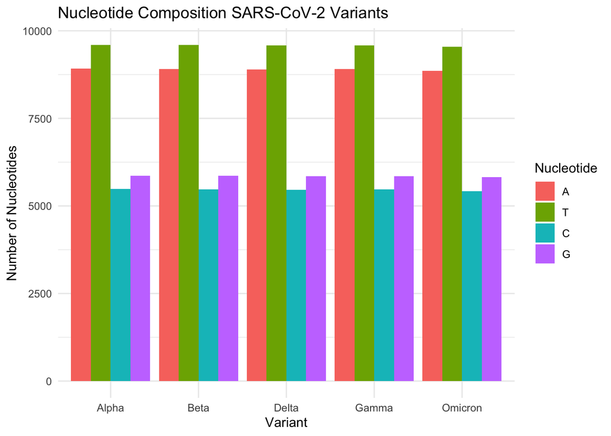

```r
composition_df <- do.call(rbind, lapply(names(variant_results), function(name) {
  data.frame(
    Variant = name,
    t(as.data.frame(variant_results[[name]]$composition))
  )
}))

composition_melt <- melt(composition_df, id.vars = "Variant")

ggplot(composition_melt, aes(x = Variant, y = value, fill = variable)) +
  geom_bar(stat = "identity", position = "dodge") +
  labs(title = "Nucleotide Composition SARS-CoV-2 Variants",
       y = "Number of Nucleotides", x = "Variant", fill = "Nucleotide") +
  theme_minimal()
```

# Interpretación de la gráfica: # Esta gráfica compara la cantidad de A T C G que tiene cada variante de SARS-CoV-2, la gráfica para cada variante a simple vista se ven iguales, aunque no lo son, simplemente tienen una diferencia de nada, para saber bien que cantidad tiene cada uno, no creo que esta gráfica nos sirva muy bien ya que no podemos distinguir las diferencias.